# Github and R Markdown for Research Productivity, Transparency, and Reproducibility

2/6/2020

## Introduction

## Tutorial Set-up

Hopefully you are already done the following things:

- Create a free github account
- Install R and Rstudio
- Install Git
- Connect R to Github

If not, work on that now. It may take a little while to link R and Github. I can help during our first break.

Here is a link to the github repo for this tutorial:

https://github.com/jeff-dotson/tilburg-training

## Motivation for Using Github

- Increase productivity, especially when collaborating with co-authors
- Increase transparency and reproducibility
- Increase the visibility of our work (private work offers little value to the rest of society)

## Concerns you might have

- Someone might steal my work!
- What if someone finds and error?!
- I don’t want people to see that I’m not a good programmer!

## Workflow

What does your workflow look like?

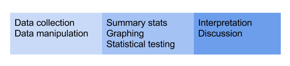

## Workflow - Crazy

Does it look someting like this?

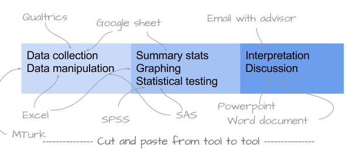

## Workflow - Better

Would it be better if it looked a little like this?

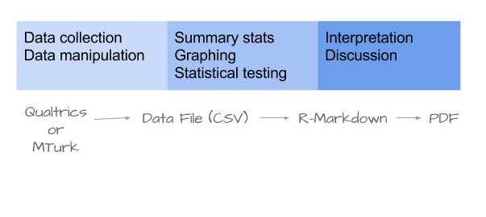

## Github and Rstudio

## Introduction to R and RStudio

A quick tour of RStudio

## Getting Started with Github

GitHub is a powerful collaboration and version control tool.

We will be using it for:

- **project management**
- **writing**
- **coding**

## Project Management

By project management I primarily mean keeping track of assigned tasks using the **Issues** tab on GitHub.

We can have an ongoing conversation here about each specific issue and close it out when its completed or resolved.

Be sure to tag collaborators you want to see the conversation (e.g., `@jeff-dotson`).

Think of this as an email thread or Slack channel where all of the conversations are in one place, easily searchable, and automatically archived.

## Project Management - Illustration

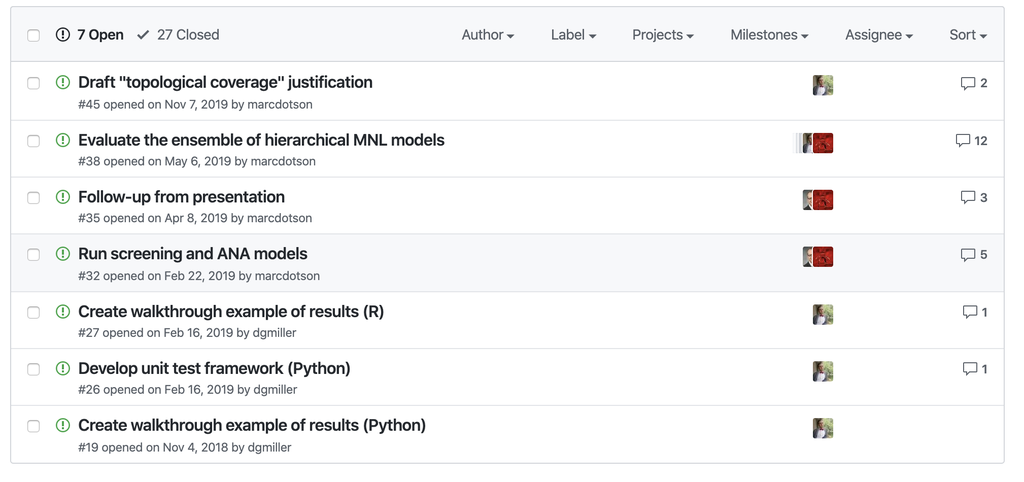

## Writing

Think of using GitHub to collaborate on writing like using something like Google Docs.

It is essential that we document what we’re doing in each project as we do it. This is true for a number of reasons:

1. Writing forces you to think clearly about what you’re doing.
2. If you’re coding, think of the associated writing as long-form comments.
3. The final product of any project is going to be a paper, so start writing it now.

## Writing

GitHub supports **markdown** syntax, which you’re probably more familiar with than you might expect.

The output is defined in the **YAML**, the header at the top, should always be set to `output: github_document`.

When you knit changes to your R Markdown document, it will create a markdown document that is easy for GitHub to read.

## Writing Illustration

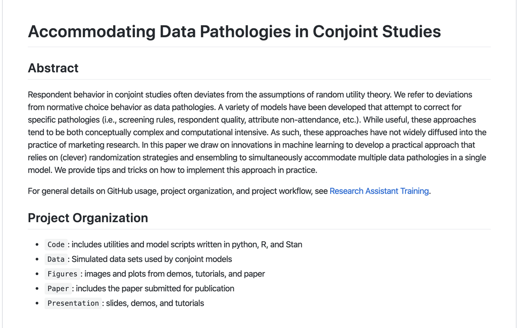

## Coding

GitHub was created for software developers. While we aren’t developing software, we will be importing, wrangling, visualizing, and modeling data.

Even if you were just working solo, you will be collaborating with your past self and you should do yourself a favor and impose good version controls on your code.

R Markdown allows us to integrate executable code directly into a document.

## Coding - Illustration

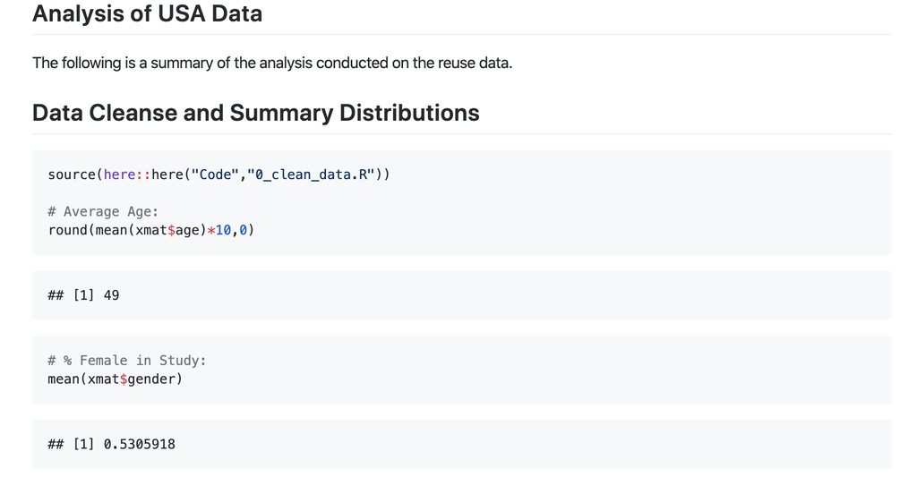

## Getting Started with Github - Clone a Repo

First **fork** and then **clone** the repo for this tutorial.

https://github.com/jeff-dotson/tilburg-training

This creates a local copy of the repo.

You do this inside RStudio by creating a new project and selecting `Version Control > Git`.

## Git Basics - Clone a Repo

[figure not shown]

## Daily Work: Pull, Commit, Push

[figure not shown]

## Daily Work: Pull, Commit, Push

When you start a new work session, you’ll want to click on the blue down arrow to **pull** the latest changes from the repo, possibly the work other collaborators have pushed, so you’re synced.

## Daily Work: Pull, Commit, Push

Open up the RStudio Project in the clone and work on the project.

You have a new Git pane in RStudio that notifies you that changes you’ve made means you are out-of-sync with the **remote** repo (i.e., the one on GitHub).

Once you’ve made a number of changes, you click on the files you want to **commit** and click commit.

Think of a **commit** as saving a snapshot of all of the changes you’ve made across these files all at once.

Include a clear commit message. You’ll do this fairly frequently for your local repo, possibly just **amending** the same commit each time.

## Daily Work: Pull, Commit, Push

Eventually you’ll be ready for other people to have access to your changes on the remote repo.

To do this, you’ll click on the green up arrow to **push** your changes to the remote repo.

You push far less often than you commit, maybe once a work session, since this means you think it’s ready for others to have access to.

Each time you push, all of your commits are archived on the remote repo, including the **diff** or the side-by-side comparison of what changes you made to the previous version.